# team.Rmd

Grant Ruedy and Andrew Sundberg

2/5/2019

1. What is the overall number of chocolate bars rated?

```r
choco <- read.csv("https://xdaiisu.github.io/ds202materials/hwlabs/choco.csv")
head(choco)
```

```
##    Company Specific.Bean.Origin  REF Review.Date Cocoa.Pct
## 1 A. Morin          Agua Grande 1876        2016        63
## 2 A. Morin                Kpime 1676        2015        70
## 3 A. Morin               Panama 1011        2013        70
## 4 A. Morin           Madagascar 1011        2013        70
## 5 A. Morin               Brazil 1011        2013        70
## 6 A. Morin             Equateur 1011        2013        70
##   Company.Location Rating Bean.Type Broad.Bean.Origin
## 1           France   3.75                    Sao Tome
## 2           France   2.75                        Togo
## 3           France   2.75                      Panama
## 4           France   3.00   Criollo        Madagascar
## 5           France   3.25                      Brazil
## 6           France   3.75                     Ecuador
```

```r
str(choco)
```

```
## 'data.frame':    1852 obs. of  9 variables:
##  $ Company             : Factor w/ 431 levels "A. Morin","Acalli",..: 1 1 1 1 1 1 1 1 1 1 ...
##  $ Specific.Bean.Origin: Factor w/ 1067 levels "\"heirloom\", Arriba Nacional",..: 15 504 752 578 138 366 251 119 760 217 ...
##  $ REF                 : int  1876 1676 1011 1011 1011 1011 1015 1015 1015 1015 ...
##  $ Review.Date         : int  2016 2015 2013 2013 2013 2013 2013 2013 2013 2013 ...
##  $ Cocoa.Pct           : num  63 70 70 70 70 70 70 70 70 70 ...
##  $ Company.Location    : Factor w/ 61 levels "Amsterdam","Argentina",..: 19 19 19 19 19 19 19 19 19 19 ...
##  $ Rating              : num  3.75 2.75 2.75 3 3.25 3.75 2.75 3 3.25 4 ...
##  $ Bean.Type           : Factor w/ 41 levels "","Amazon","Amazon mix",..: 1 1 1 9 1 1 1 1 1 34 ...
##  $ Broad.Bean.Origin   : Factor w/ 100 levels "","Africa, Carribean, C. Am.",..: 69 79 54 47 6 23 12 7 55 92 ...
```

There are 1852 chocolate bars being rated.

2. How does the number of ratings depend on the year? Draw a bar chart of the number of reports.

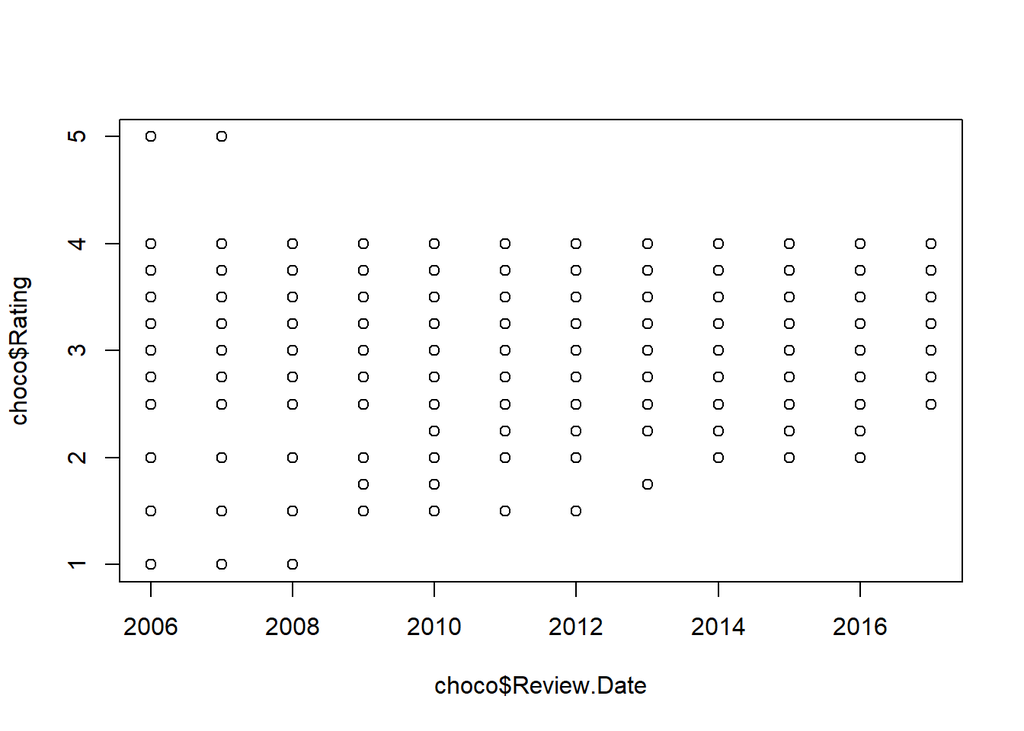

```r
plot(choco$Review.Date, choco$Rating)
```

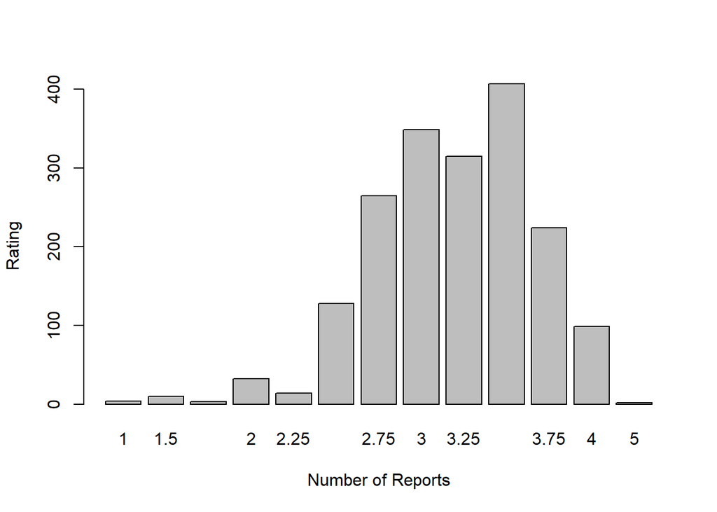

```r
x <- table(choco$Rating)
barplot(x, xlab= 'Number of Reports', ylab='Rating')
```

By looking at the scatterplot of ratings and review date (year), there appears to be no relationship between the two variables.

3.How do ratings compare across different company locations?

```r
summary(choco)
```

```
##      Company             Specific.Bean.Origin      REF
##  Soma    :  47   Madagascar        :  58      Min.   :   5
##  Bonnat  :  27   Peru              :  45      1st Qu.: 600
##  Fresco  :  26   Ecuador           :  43      Median :1099
##  Pralus  :  25   Dominican Republic:  39      Mean   :1065
##  A. Morin:  23   Venezuela         :  21      3rd Qu.:1546
##  Arete   :  22   Chuao             :  20      Max.   :2008
##  (Other) :1682   (Other)           :1626
##   Review.Date     Cocoa.Pct     Company.Location     Rating
##  Min.   :2006   Min.   : 42.0   U.S.A. :787      Min.   :1.000
##  1st Qu.:2010   1st Qu.: 70.0   France :158      1st Qu.:3.000
##  Median :2013   Median : 70.0   Canada :132      Median :3.250
##  Mean   :2012   Mean   : 71.7   U.K.   : 98      Mean   :3.191
##  3rd Qu.:2015   3rd Qu.: 75.0   Italy  : 69      3rd Qu.:3.500
##  Max.   :2017   Max.   :100.0   Ecuador: 55      Max.   :5.000
##                                 (Other):553
##                 Bean.Type            Broad.Bean.Origin
##                      :938   Venezuela         :217
##  Trinitario          :421   Ecuador           :198
##  Criollo             :153   Peru              :171
##  Forastero           : 87   Madagascar        :147
##  Forastero (Nacional): 52   Dominican Republic:145
##  Blend               : 42                     : 74
##  (Other)             :159   (Other)           :900
```

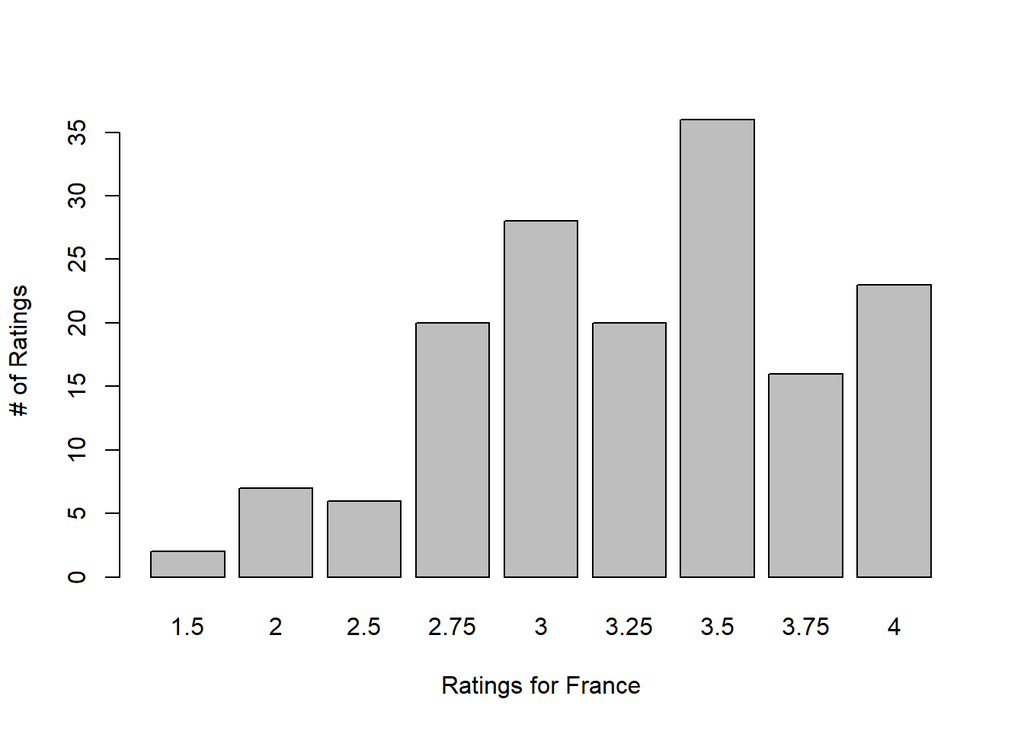

```r
France <- choco[choco$Company.Location =='France',]
USA <- choco[choco$Company.Location =='U.S.A.',]
Canada <-choco[choco$Company.Location =='Canada',]

a <-table(France$Rating)
b <-table(USA$Rating)
c <- table(Canada$Rating)

barplot(a, xlab= 'Ratings for France', ylab='# of Ratings')
```

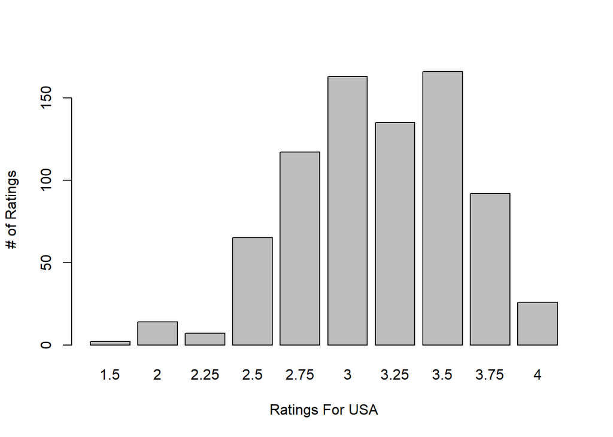

```r
barplot(b, xlab= 'Ratings For USA', ylab='# of Ratings')
```

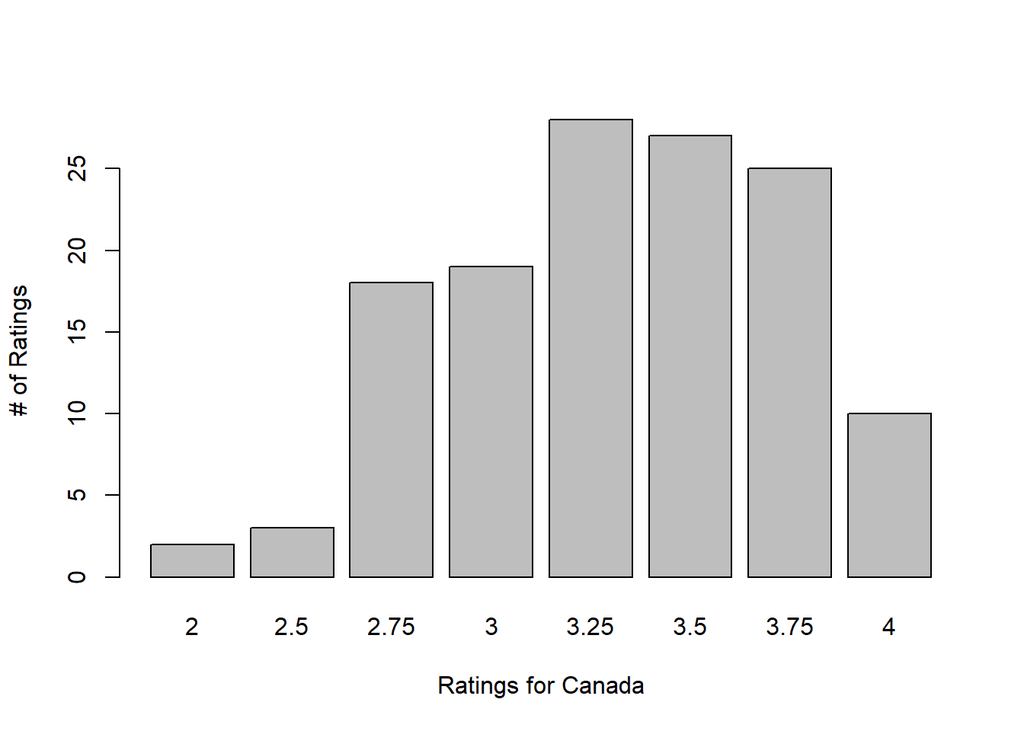

```r
barplot(c, xlab= 'Ratings for Canada', ylab='# of Ratings')
```

```r
summary(France)
```

```
##                              Company             Specific.Bean.Origin
##  Bonnat                          :27   Equateur            :  5
##  Pralus                          :25   Madagascar          :  5
##  A. Morin                        :23   Chuao               :  4
##  Valrhona                        :22   Cuba                :  4
##  La Maison du Chocolat (Valrhona):10   Chanchamayo Province:  2
##  Laia aka Chat-Noir              :10   Colombie            :  2
##  (Other)                         :41   (Other)             :136
##       REF          Review.Date     Cocoa.Pct       Company.Location
##  Min.   :   5.0   Min.   :2006   Min.   : 55.00   France   :158
##  1st Qu.: 130.5   1st Qu.:2007   1st Qu.: 68.00   Amsterdam:  0
##  Median : 629.0   Median :2011   Median : 73.00   Argentina:  0
##  Mean   : 712.4   Mean   :2010   Mean   : 71.71   Australia:  0
##  3rd Qu.:1201.0   3rd Qu.:2014   3rd Qu.: 75.00   Austria  :  0
##  Max.   :1992.0   Max.   :2017   Max.   :100.00   Belgium  :  0
##                                                   (Other)  :  0
##      Rating                    Bean.Type   Broad.Bean.Origin
##  Min.   :1.500                      :78   Venezuela :23
##  1st Qu.:3.000   Trinitario         :36   Peru      :14
##  Median :3.250   Criollo            :15             :12
##  Mean   :3.253   Forastero          :12   Madagascar:12
##  3rd Qu.:3.500   Criollo (Porcelana): 6   Ecuador   : 9
##  Max.   :4.000   Blend              : 3   Brazil    : 8
##                  (Other)            : 8   (Other)   :80
```

```r
summary(USA)
```

```
##              Company            Specific.Bean.Origin      REF
##  Fresco          : 26   Dominican Republic: 26       Min.   :   5
##  Arete           : 22   Ecuador           : 25       1st Qu.: 785
##  Guittard        : 22   Madagascar        : 23       Median :1235
##  Mast Brothers   : 18   Peru              : 21       Mean   :1158
##  Scharffen Berger: 17   Belize            : 12       3rd Qu.:1558
##  Dandelion       : 16   Sambirano         : 11       Max.   :2008
##  (Other)         :666   (Other)           :669
##   Review.Date     Cocoa.Pct       Company.Location     Rating
##  Min.   :2006   Min.   : 55.00   U.S.A.   :787     Min.   :1.500
##  1st Qu.:2011   1st Qu.: 70.00   Amsterdam:  0     1st Qu.:2.750
##  Median :2014   Median : 70.00   Argentina:  0     Median :3.250
##  Mean   :2013   Mean   : 71.53   Australia:  0     Mean   :3.162
##  3rd Qu.:2015   3rd Qu.: 74.00   Austria  :  0     3rd Qu.:3.500
##  Max.   :2017   Max.   :100.00   Belgium  :  0     Max.   :4.000
##                                  (Other)  :  0
##                 Bean.Type            Broad.Bean.Origin
##                      :464   Dominican Republic: 97
##  Trinitario          :166   Peru              : 78
##  Criollo             : 41   Venezuela         : 75
##  Forastero           : 27   Ecuador           : 74
##  Blend               : 22   Madagascar        : 58
##  Forastero (Nacional): 22   Bolivia           : 38
##  (Other)             : 45   (Other)           :367
```

```r
summary(Canada)
```

```
##             Company                       Specific.Bean.Origin
##  Soma           :47   Dominican Republic            :  6
##  Palette de Bine:14   Papua New Guinea              :  5
##  Sirene         :12   Madagascar                    :  4
##  Habitual       : 9   Camino Verde P., Balao, Guayas:  3
##  Hummingbird    : 8   Ocumare                       :  3
##  Ambrosia       : 6   Somia Plantation, 2012        :  3
##  (Other)        :36   (Other)                       :108
##       REF        Review.Date     Cocoa.Pct       Company.Location
##  Min.   : 377   Min.   :2009   Min.   : 62.00   Canada   :132
##  1st Qu.:1027   1st Qu.:2013   1st Qu.: 70.00   Amsterdam:  0
##  Median :1307   Median :2014   Median : 70.00   Argentina:  0
##  Mean   :1279   Mean   :2014   Mean   : 72.42   Australia:  0
##  3rd Qu.:1614   3rd Qu.:2015   3rd Qu.: 74.00   Austria  :  0
##  Max.   :2004   Max.   :2017   Max.   :100.00   Belgium  :  0
##                                                 (Other)  :  0
##      Rating                     Bean.Type           Broad.Bean.Origin
##  Min.   :2.000                       :68   Dominican Republic:15
##  1st Qu.:3.000   Trinitario          :31   Venezuela         :14
##  Median :3.250   Criollo             :12   Madagascar        : 9
##  Mean   :3.312   Forastero           : 6                     : 8
##  3rd Qu.:3.750   Blend               : 5   Ecuador           : 8
##  Max.   :4.000   Forastero (Nacional): 3   Peru              : 8
##                  (Other)             : 7   (Other)           :70
```

4. Is there a difference in ratings between criollo and trinitario beans?

```r
cri = choco[choco$Bean.Type =='Criollo',]
trin = choco[choco$Bean.Type == 'Trinitario',]
summary(cri)
```

```
##               Company    Specific.Bean.Origin      REF
##  Soma             :  8   Ocumare  :  8        Min.   :   5.0
##  Idilio (Felchlin):  6   Peru     :  6        1st Qu.: 395.0
##  Pierre Marcolini :  6   Porcelana:  6        Median : 883.0
##  Bonnat           :  5   Tumbes   :  5        Mean   : 895.3
##  Domori           :  5   Patanemo :  4        3rd Qu.:1319.0
##  Duffy's          :  5   Chuao    :  3        Max.   :1912.0
##  (Other)          :118   (Other)  :121
##   Review.Date     Cocoa.Pct         Company.Location     Rating
##  Min.   :2006   Min.   : 58.00   U.S.A.     :41      Min.   :2.00
##  1st Qu.:2009   1st Qu.: 70.00   France     :15      1st Qu.:3.00
##  Median :2012   Median : 71.00   Canada     :12      Median :3.25
##  Mean   :2012   Mean   : 72.01   Switzerland:12      Mean   :3.24
##  3rd Qu.:2014   3rd Qu.: 75.00   Belgium    :10      3rd Qu.:3.50
##  Max.   :2016   Max.   :100.00   U.K.       :10      Max.   :4.00
##                                  (Other)    :53
##        Bean.Type    Broad.Bean.Origin
##  Criollo    :153   Venezuela :58
##             :  0   Peru      :38
##  Amazon     :  0   Madagascar:13
##  Amazon mix :  0   Mexico    :12
##  Amazon, ICS:  0   Bolivia   : 7
##  Beniano    :  0   Indonesia : 5
##  (Other)    :  0   (Other)   :20
```

```r
summary(trin)
```

```
##        Company    Specific.Bean.Origin      REF        Review.Date
##  Fresco    : 13   Madagascar: 50       Min.   :   5   Min.   :2006
##  Soma      : 13   Sambirano : 17       1st Qu.: 593   1st Qu.:2010
##  Marou     : 10   Chuao     : 15       Median :1117   Median :2013
##  Pralus    :  9   Belize    : 13       Mean   :1030   Mean   :2012
##  Domori    :  7   Trinidad  : 11       3rd Qu.:1486   3rd Qu.:2015
##  Castronovo:  6   Grenada   : 10       Max.   :1976   Max.   :2017
##  (Other)   :363   (Other)   :305
##    Cocoa.Pct       Company.Location     Rating            Bean.Type
##  Min.   : 55.00   U.S.A.   :166     Min.   :1.750   Trinitario :421
##  1st Qu.: 70.00   France   : 36     1st Qu.:3.000              :  0
##  Median : 70.00   Canada   : 31     Median :3.250   Amazon     :  0
##  Mean   : 71.73   U.K.     : 28     Mean   :3.245   Amazon mix :  0
##  3rd Qu.: 75.00   Australia: 18     3rd Qu.:3.500   Amazon, ICS:  0
##  Max.   :100.00   Italy    : 17     Max.   :5.000   Beniano    :  0
##                   (Other)  :125                     (Other)    :  0
##   Broad.Bean.Origin
##  Madagascar:110
##  Venezuela : 57
##  Belize    : 39
##  Vietnam   : 38
##  Trinidad  : 33
##  Jamaica   : 19
##  (Other)   :125
```

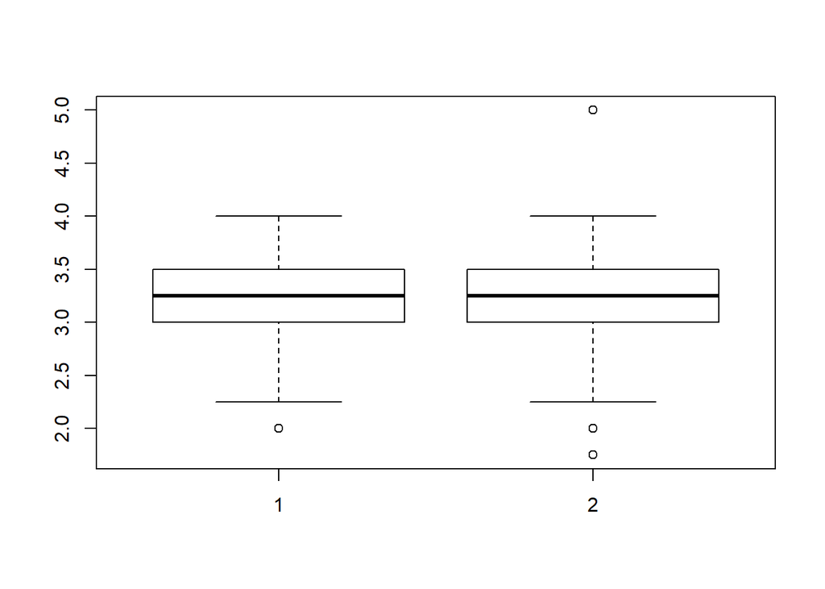

```r
boxplot(cri$Rating, trin$Rating)
```

Boxplot one represents criollo beans and boxplot two represents trinitario beans. As you can see, their means are approximately the same. Criollo beans have a mean of 3.24 and Trinitario beans have a mean of 3.245. With the exception of a few outliers, the two boxplots look itentical. Therefore, the ratings do not differ between the beans.